# Causal Support: E2 Stimuli and Task Structure

Alex Kale

2021-03-29

## Overview: Causal support as benchmark for causal induction

The core idea of this study is to see what we can learn by using *causal support*, as defined by [Griffiths and Tenenbaum](https://web.mit.edu/cocosci/Papers/structure-strength-reprint.pdf), as a normative benchmark for causal induction tasks with visualizations, where chart users attempt to reason about the causal structure underlying data.

Following Griffiths and Tenenbaum, we will present participants with scenarios involving two alternative causal explanations for data, represented by directed acyclic graphs (DAGs), and we will ask them to say the probability that one of those graphs vs the other generated a given data set. We will evaluate these elicited probabilities by comparing them to *causal support*, which is the log likelihood ratio of the data given the two alternative models. While this can be extended to use cases with more than two models, we will focus on toy problems for causal induction to learn what we can as a proof of concept for causal support as an evaluation strategy for causal reasoning with visualizations.

In this document, we plan the data and alternative models we will show participants. Our aim is to plan a trial structure and the copy for a crowdsourced experiment. Adapting tasks from Griffiths and Tenenbaum, as well as Wu, we will ask participants to look at two-way tables or linked bar charts showing counts of people with and without disease, given the presence or absence of a gene and the presence or absence of treatment. On each trial we, will show a fake data set and ask for a probability judgment.

## Task Scenario: Does the gene both cause the disease and block the treatment effect?

The copy for this problem will be: *“A company has hired you to help them analyze 18 data sets that they’ve collected about the impact of different genes on different treatments and diseases. The company knows that a particular treatment protects against each disease in about 80% of people who receive treatment. The company wants your help figuring out whether various genes are interfering with their treatments and if these genes also cause the diseases that treatments protect against.”*

Before we get into generating fake data, we need a way of evaluating the ground truth probability of confounding.

### Monte Carlo simulations

To operationalize a normative judgment on this task, we set up a Monte Carlo simulation for each alternative DAG or hypothesis about causal structure. We represent each DAG as a parameterized simulation where we calculate the log likelihood of the data by integrating over a uniform prior on parameter values. Note that unlike Griffiths and Tenenbaum, we are assuming that there is a base rate of the effect (disease) that is not explained by the covariate (gene).

```r
# expects data as counts from a two-way table formatted as follows:
#   count_nGnT  - count with disease given gene F and treatment F
#   total_nGnT  - total given gene F and treatment F
#   count_nGT   - count with disease given gene F and treatment T
#   total_nGT   - total given gene F and treatment T
#   count_GnT   - count with disease given gene T and treatment F
#   total_GnT   - total given gene T and treatment F
#   count_GT    - count with disease given gene T and treatment T
#   total_GT    - total given gene T and treatment T
# the booleans gene_impacts_d and gene_impacts_t determine which DAG is simulated
likelihood_from_monte_carlo <- function (count_nGnT, total_nGnT, count_nGT, total_nGT, count_GnT, total_GnT, count_GT, total_GT, gene_impacts_d = TRUE, gene_impacts_t = TRUE) {
  # define parameters (sample from uniform distribution)
  m <- 10000              # number of simulations
  p_disease <- runif(m)   # base rate of disease due to unknown causes
  p_treat <- runif(m)     # probability that treatment prevents disease
  if (gene_impacts_d) {
    p_gene_d <- runif(m)  # probability that gene causes disease
  } else {
    p_gene_d <- rep(0, m) # gene has no effect on disease
  }
  if (gene_impacts_t) {
    p_gene_t <- runif(m)  # probability that gene prevents treatment from working
  } else {
    p_gene_t <- rep(0, m)  # gene has no effect on treatment
  }


  # calculate counts for each possible outcome in the contingency table
  counts <- cbind(
    count_nGnT,
    total_nGnT - count_nGnT,
    count_nGT,
    total_nGT - count_nGT,
    count_GnT,
    total_GnT - count_GnT,
    count_GT,
    total_GT - count_GT
  )

  # calculate probabilies for each possible outcome in the contingency table
  probs <- cbind(
    p_disease,                                                                      # p(disease|gene F, treatment F)
    (1 - p_disease),                                                                # p(~disease|gene F, treatment F)
    p_disease*(1 - p_treat),                                                        # p(disease|gene F, treatment T)
    (1 - p_disease) + p_disease*p_treat,                                            # p(~disease|gene F, treatment T)
    p_gene_d + p_disease - p_gene_d*p_disease,                                      # p(disease|gene T, treatment F)
    (1 - p_gene_d)*(1 - p_disease),                                                 # p(~disease|gene T, treatment F)
    # delta from E1:
    (p_gene_d + p_disease - p_gene_d*p_disease)*((1 - p_treat) + p_treat*p_gene_t), # p(disease|gene T, treatment T)
    (1 - p_gene_d)*(1 - p_disease) + (p_gene_d + p_disease - p_gene_d*p_disease)*(p_treat*(1 - p_gene_t)) # p(~disease|gene T, treatment T)
  )

  # calculate log likelihood of data for each of m runs of the simulation
  loglik <- rowSums(matrix(rep(counts, m), nrow = m, ncol = 8, byrow = TRUE) * log(probs))
  # normalize by maximum likelihood to make probabilities comparable across Monte Carlo simulations
  # and marginalize over simulated parameter values
  logmax <- max(loglik)
  logscore <- logmax + log(sum(exp(loglik - logmax))) - log(m)
}
```

Now we can generate fake data sets and calculate how much causal support there is for confounding. This enables to establish a normative benchmark for responses.

### Trial structure

Lets generate a bunch of stimuli based on a set of parameters. We’ll add sampling error by drawing events from a binomial distribution, except in the case of the base rate of treatment because we will always present a balanced sample.

```r
# number of simulated data sets per combination of factors
n_sims <- 2000

# set up manipulations and simulate fake data
stim2_df <- expand.grid(
    p_gene_d = c(0, 0.35, 0.7), # gene effect on disease (3 levels)
    p_gene_t = c(0, 0.35, 0.7), # gene effect on disease (3 levels)
    br_gene = 0.4,              # base rate of gene (control)
    p_treat = 0.8,              # treatment effect (control)
    br_treat = 0.5,             # base rate of treatment (control, no noise)
    p_disease = 0.2,            # base rate of disease (control)
    N = c(100, 1000)            # sample size (2 levels)
  ) %>%
  rowid_to_column("trialIdx") %>%
  rowwise() %>%
  mutate(
    # get a balanced sample of people do and do not receive treatment
    nTreat = round(N*br_treat),
    nNoTreat = round(N*(1 - br_treat)),
    # sample possible numbers of people in each group who have the gene
    draw = list(seq(from = 1, to = n_sims, by = 1)),
    total_GnT = list(rbinom(n_sims, nNoTreat, br_gene)), # N(gene T, treatment F)
    total_GT = list(rbinom(n_sims, nTreat, br_gene))     # N(gene T, treatment T)
  ) %>%
  unnest(cols = c("draw", "total_GT", "total_GnT")) %>%
  mutate(
    # calculate number of people in each group who DO NOT have the gene for each draw
    total_nGnT = nNoTreat - total_GnT, # N(gene F, treatment F)
    total_nGT = nTreat - total_GT      # N(gene F, treatment T)
  ) %>%
  rowwise() %>%
  mutate(
    count_nGnT = rbinom(1, total_nGnT, p_disease),                                            # N(disease|gene F, treatment F)
    count_nGT = rbinom(1, total_nGT, p_disease*(1 - p_treat)),                                # N(disease|gene F, treatment T)
    count_GnT = rbinom(1, total_GnT, (p_gene_d + p_disease - p_gene_d*p_disease)),            # N(disease|gene T, treatment F)
    # delta from E1
    count_GT = rbinom(1, total_GT, (p_gene_d + p_disease - p_gene_d*p_disease)*((1 - p_treat) + p_treat*p_gene_t)) # N(disease|gene T, treatment T)
  ) %>%
  # drop intermediate calculations
  select(-one_of(c("nTreat", "nNoTreat")))

head(stim2_df)
```

```
## # A tibble: 6 x 17
## # Rowwise:
##   trialIdx p_gene_d p_gene_t br_gene p_treat br_treat p_disease     N  draw
##      <int>    <dbl>    <dbl>   <dbl>   <dbl>    <dbl>     <dbl> <dbl> <dbl>
## 1        1        0        0     0.4     0.8      0.5       0.2   100     1
## 2        1        0        0     0.4     0.8      0.5       0.2   100     2
## 3        1        0        0     0.4     0.8      0.5       0.2   100     3
## 4        1        0        0     0.4     0.8      0.5       0.2   100     4
## 5        1        0        0     0.4     0.8      0.5       0.2   100     5
## 6        1        0        0     0.4     0.8      0.5       0.2   100     6
## # … with 8 more variables: total_GnT <int>, total_GT <int>, total_nGnT <dbl>,
## #   total_nGT <dbl>, count_nGnT <int>, count_nGT <int>, count_GnT <int>,
## #   count_GT <int>
```

Now, let’s calculate causal support for each simulated data set.

```r
stim2_df = stim2_df %>%
  rowwise() %>%
  mutate(
    # calculate log likelihood ratio of data under confounding model vs *disjunction* of all others, preventing values of inf
    llA = likelihood_from_monte_carlo(count_nGnT, total_nGnT, count_nGT, total_nGT, count_GnT, total_GnT, count_GT, total_GT, FALSE, FALSE),
    llB = likelihood_from_monte_carlo(count_nGnT, total_nGnT, count_nGT, total_nGT, count_GnT, total_GnT, count_GT, total_GT, TRUE, FALSE),
    llC = likelihood_from_monte_carlo(count_nGnT, total_nGnT, count_nGT, total_nGT, count_GnT, total_GnT, count_GT, total_GT, FALSE, TRUE),
    llD = likelihood_from_monte_carlo(count_nGnT, total_nGnT, count_nGT, total_nGT, count_GnT, total_GnT, count_GT, total_GT, TRUE, TRUE),
    # calculate causal support for confounding
    llmaxABC = max(llA, llB, llC),
    llABC = llmaxABC + log(exp(llA - llmaxABC) + exp(llB - llmaxABC) + exp(llC - llmaxABC)), # trick to avoid exp() => 0 for small ll
    # causal support as Bayesian update assuming a uniform prior across 4 DAGs
    causal_support = (llD - llABC) + (log(0.25) - log(0.25 + 0.25 + 0.25)),
    # convert causal support into normative probability judgment for explanation D
    ground_truth = plogis(causal_support),
    # calculate causal support for gene effect on disease
    llmaxBD = max(llB, llD),
    llBD = llmaxBD + log(exp(llB - llmaxBD) + exp(llD - llmaxBD)),
    llmaxAC = max(llA, llC),
    llAC = llmaxAC + log(exp(llA - llmaxAC) + exp(llC - llmaxAC)),
    causal_support_d = (llBD - llAC) + (log(0.25 + 0.25) - log(0.25 + 0.25)),
    # calculate causal support for gene effect on treatment
    llmaxCD = max(llC, llD),
    llCD = llmaxCD + log(exp(llC - llmaxCD) + exp(llD - llmaxCD)),
    llmaxAB = max(llA, llB),
    llAB = llmaxAB + log(exp(llA - llmaxAB) + exp(llB - llmaxAB)),
    causal_support_t = (llCD - llAB) + (log(0.25 + 0.25) - log(0.25 + 0.25))
  ) %>%
  # drop the columns for intermediate calculations
  select(-one_of(c("llmaxABC", "llABC", "llmaxBD", "llBD", "llmaxAC", "llAC", "llmaxCD", "llCD", "llmaxAB", "llAB")))
```

While we want our stimuli to reflect natural sampling error, we also want to counterbalance that sampling error within each data condition across participants. In order to do this, we’ll reduce our stimulus data from a distribution of draws to a set of quantiles of ground truth causal support that we can sample systematically.

```r
# generate a list of probabilities corresponding to a number of quantiles equal to the number of unique data conditions
n_quantiles <- max(stim2_df$trialIdx)
p <- ppoints(n_quantiles)

# generate a dataframe containing quantiles for each data condition
quantiles2_df <- stim2_df %>%
  group_by(trialIdx) %>%
  summarise(
    qIdx = list(seq(from = 1, to = n_quantiles, by = 1)),
    q = list(quantile(causal_support, p))
  )
```

```r
# filter draws of possible stimuli to include only our quantiles
stim2_df_filtered <- stim2_df %>%
  # first we need to group our stimuli dataframe the same way as our quantile dataframe without loosing any columns
  group_by(trialIdx, p_gene_d, p_gene_t, br_gene, p_treat, br_treat, p_disease, N) %>%
  summarise(
    draw = list(draw),
    total_nGnT = list(total_nGnT),
    total_nGT = list(total_nGT),
    total_GnT = list(total_GnT),
    total_GT = list(total_GT),
    count_nGnT = list(count_nGnT),
    count_nGT = list(count_nGT),
    count_GnT = list(count_GnT),
    count_GT = list(count_GT),
    llA = list(llA),
    llB = list(llB),
    llC = list(llC),
    llD = list(llD),
    causal_support = list(causal_support),
    ground_truth = list(ground_truth),
    causal_support_d = list(causal_support_d),
    causal_support_t = list(causal_support_t)
  ) %>%
  # join stimuli data with quantiles, and make rows represent data conditions x quantiles
  full_join(quantiles2_df, by = c("trialIdx")) %>%
  unnest(cols = c("qIdx","q")) %>%
  # find the draws that are closest to our quantiles for each data condition
  rowwise() %>%
  mutate(
    draws_diff_from_q = list(lapply(causal_support, function(x) abs(x - q) )),
    which_draw = which.min(unlist(draws_diff_from_q)),
    draw = draw[[which_draw]],
    total_nGnT = total_nGnT[[which_draw]],
    total_nGT = total_nGT[[which_draw]],
    total_GnT = total_GnT[[which_draw]],
    total_GT = total_GT[[which_draw]],
    count_nGnT = count_nGnT[[which_draw]],
    count_nGT = count_nGT[[which_draw]],
    count_GnT = count_GnT[[which_draw]],
    count_GT = count_GT[[which_draw]],
    llA = llA[[which_draw]],
    llB = llB[[which_draw]],
    llC = llC[[which_draw]],
    llD = llD[[which_draw]],
    causal_support = causal_support[[which_draw]],
    ground_truth = ground_truth[[which_draw]],
    causal_support_d = causal_support_d[[which_draw]],
    causal_support_t = causal_support_t[[which_draw]]
  ) %>%
  # drop the columns we no longer need at this point
  select(-one_of(c("draw", "which_draw", "q", "draws_diff_from_q")))
```

Let’s also grab a draw to use for attention check and practice trials.

```r
# get min and max causal support values
max_cs <- max(stim2_df$causal_support)

# get data frame of practice trials
catch_df <- stim2_df %>%
  filter(causal_support == max_cs) %>%
  mutate(
    trialIdx = case_when(
      causal_support == max_cs ~ -1, # practice
      TRUE                     ~ as.numeric(trialIdx)),
    qIdx = case_when(
      causal_support == max_cs ~ -1, # practice
      TRUE                     ~ as.numeric(trialIdx))
  ) %>%
  select(-draw)

# join with filtered dataframe
stim2_df <- bind_rows(stim2_df_filtered, catch_df)
```

Now, let’s visualize the ground truth probability of confounding, which is derived from causal support, as a function of our manipulations to see how difficult our task setup is.

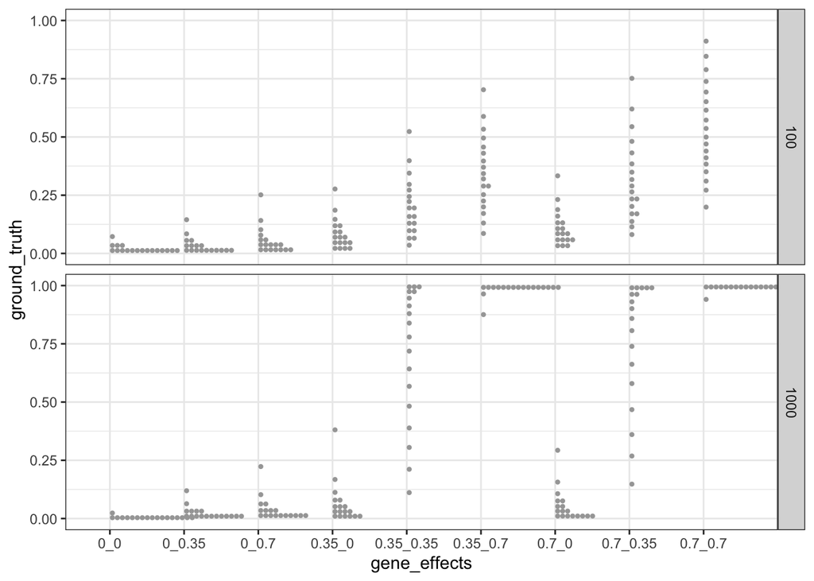

```r
stim2_df %>%
  unite("gene_effects", p_gene_d:p_gene_t, remove = FALSE) %>%
  ggplot(aes(x = gene_effects, y = ground_truth)) +
  # stat_lineribbon(.width = c(0.95, 0.8, 0.5), color = "black") +
  # scale_fill_brewer() +
  stat_dots(position = "dodge", binwidth = 0.02, quantiles = n_quantiles) +
  theme_bw() +
  facet_grid(N ~ .)
```

We can see that we are sampling a nice range of the ground truth with this trial structure.

Let’s check that a quarter of these data conditions fall above causal support of 0, ground truth of 0.5 chance of confounding. *Finding combinations of data generating parameters that meet this criterion was a matter of trial and error.*

```r
sum(stim2_df$causal_support > 0) / length(stim2_df$causal_support)
```

```
## [1] 0.2461538
```

We also want to be sure we are sampling a good range of delta p values for the impact of gene on disease and treatment, respectively.

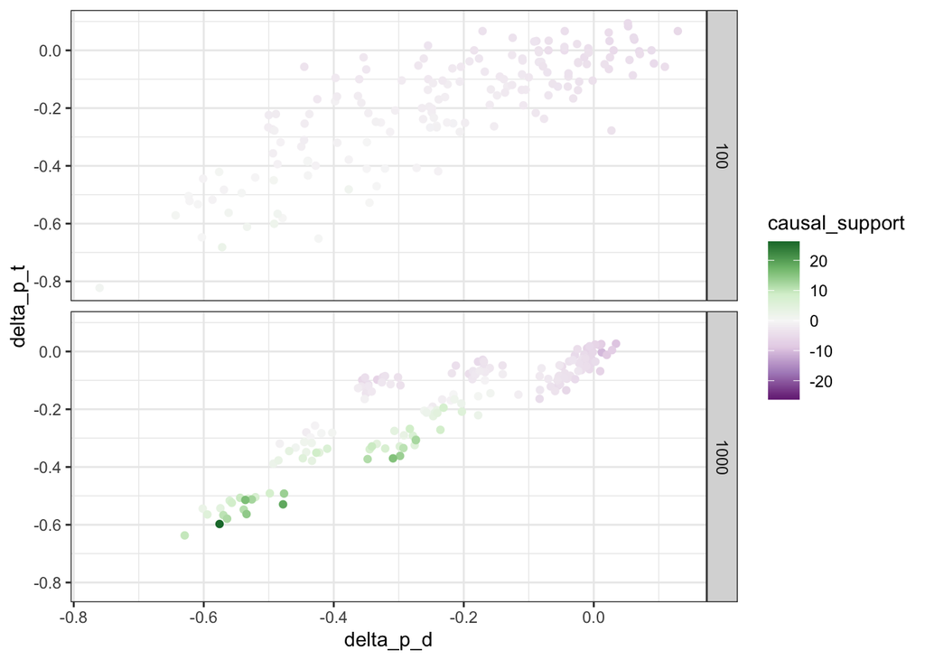

```r
stim2_df %>%
  mutate(
    delta_p_d = (count_nGnT + count_nGT) / (total_nGnT + total_nGT) - (count_GnT + count_GT) / (total_GnT + total_GT),
    delta_p_t = count_nGT / total_nGT - count_GT / total_GT
  ) %>%
  ggplot(aes(x = delta_p_d, y = delta_p_t, color = causal_support)) +
  geom_point() +
  scale_color_distiller(direction = 1, type = "div", palette = 3, limits = c(-1,1)*max(stim2_df$causal_support)) +
  theme_bw() +
  facet_grid(N ~ .)
```

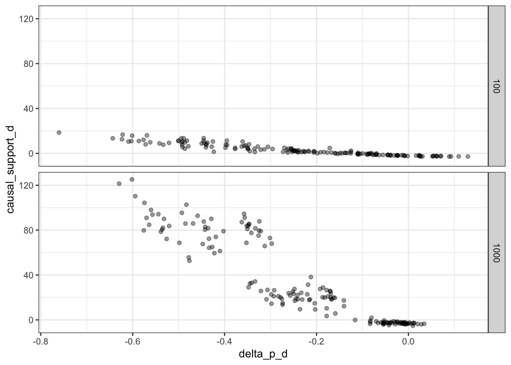

```r
stim2_df %>%
  mutate(
    delta_p_d = (count_nGnT + count_nGT) / (total_nGnT + total_nGT) - (count_GnT + count_GT) / (total_GnT + total_GT),
    delta_p_t = count_nGT / total_nGT - count_GT / total_GT
  ) %>%
  ggplot(aes(x = delta_p_d, y = causal_support_d)) +
  geom_point(alpha = 0.4) +
  theme_bw() +
  facet_grid(N ~ .)
```

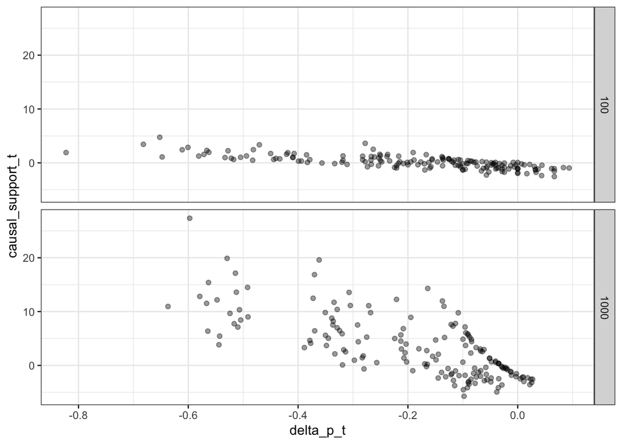

```r
stim2_df %>%
  mutate(
    delta_p_d = (count_nGnT + count_nGT) / (total_nGnT + total_nGT) - (count_GnT + count_GT) / (total_GnT + total_GT),
    delta_p_t = count_nGT / total_nGT - count_GT / total_GT
  ) %>%
  ggplot(aes(x = delta_p_t, y = causal_support_t)) +
  geom_point(alpha = 0.4) +
  theme_bw() +
  facet_grid(N ~ .)
```

```r
# stim2_df <- read_csv("/Users/kalea/Code/Projects/Temp/causal-support-experiment-interface/app/main/stimdata2.csv")

# set maxCount for non-interactive bars with scales fixed
stim2_df %>%
  mutate(
    maxCount = max(count_nGnT, (total_nGnT - count_nGnT), count_nGT, (total_nGT - count_nGT), count_GnT, (total_GnT - count_GnT), count_GT, (total_GT - count_GT))
  ) %>%
  select(maxCount) %>%
  max()
```

```
## [1] 322
```

```r
# set maxCount for interactive bars with scales fixed
stim2_df %>%
  mutate(
    maxCount = max(count_nGnT + count_nGT + count_GnT + count_GT, (total_nGnT - count_nGnT) + (total_nGT - count_nGT) + (total_GnT - count_GnT) +  (total_GT - count_GT))
  ) %>%
  select(maxCount) %>%
  max()
```

```
## [1] 897
```

```r
# set maxCount for crossfilter bars with scales fixed
stim2_df %>%
  mutate(
    maxCount = max(
      total_nGnT + total_nGT,
      total_GnT + total_GT,
      total_nGnT + total_GnT,
      total_nGT + total_GT,
      count_nGnT + count_nGT + count_GnT + count_GT,
      (total_nGnT - count_nGnT) + (total_nGT - count_nGT) + (total_GnT - count_GnT) +  (total_GT - count_GT))
  ) %>%
  select(maxCount) %>%
  max()
```

```
## [1] 897
```

We save this data to generate stimuli during the experiment.

```r
# save data as json
# write.csv(stim2_df, "stimuli/stimdata2.csv", quote = FALSE)
```